# Introduction to Open Data Science

First, we visualize the percentages of inertia explained by each MCA dimensions. We can interpret, for instance, to explain at least 50% of variances, we need at least 4 dimensions (15.3%+14.5%+11.8%+10.6%=52.2%).

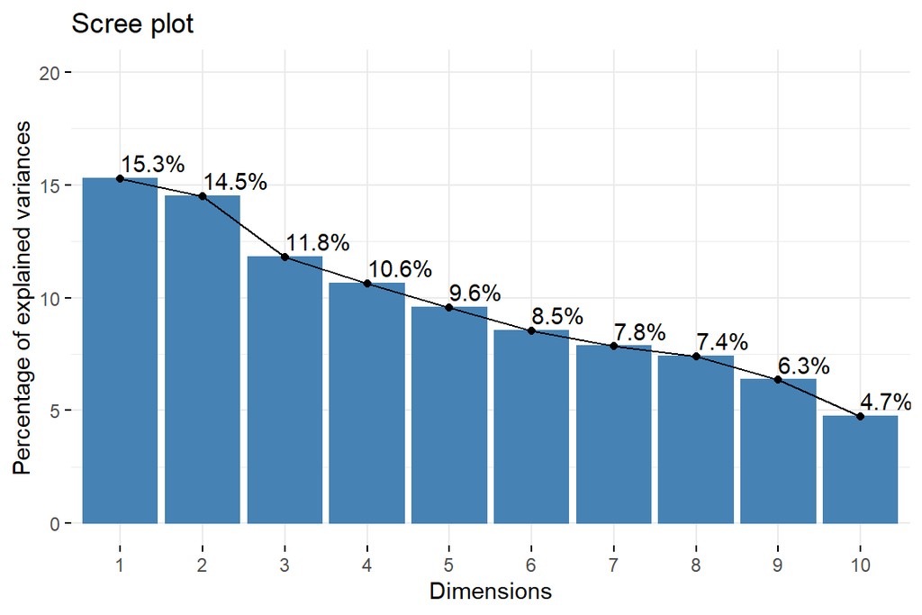

```r
# visualize MCA
fviz_screeplot(mca, addlabels = TRUE, ylim = c(0, 20))
```

Next, we draw the biplot of individuals and variable categories. The biplot below shows a global pattern within the data. Rows (individuals) are represented by blue points and columns (variable categories) by red triangles. The distances between the points, either between column points or row points, measure the similarity between them. For example, individual 191 is very similar to individual 249 and individual 22 is very dissimilar to individual 31 or 168.

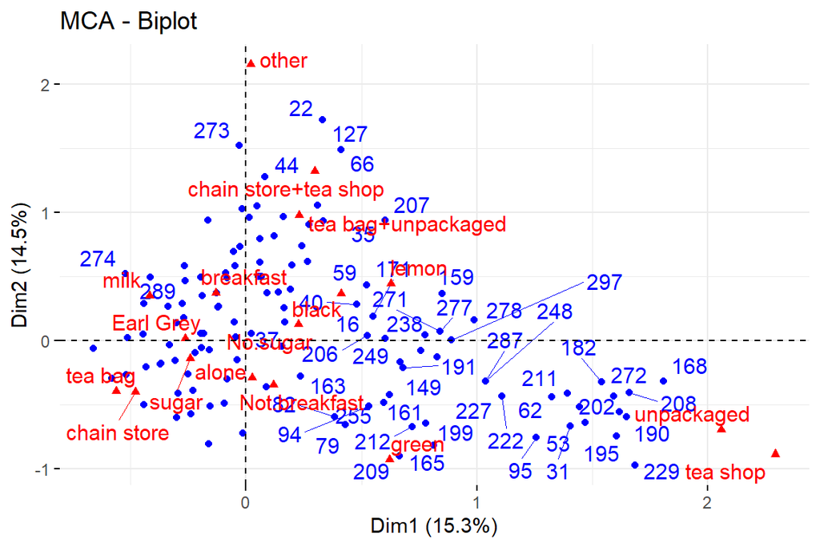

```r
# visualize MCA
fviz_mca_biplot(mca,
               repel = TRUE, # Avoid text overlapping (slow if many point)
               ggtheme = theme_minimal())
```

We can also visualize the correlation between variables and MCA principal dimensions as follows. We can see that, for instance, tea.breakfast is more correlated with dimension 2, while te.where is correlated with both dimensions.

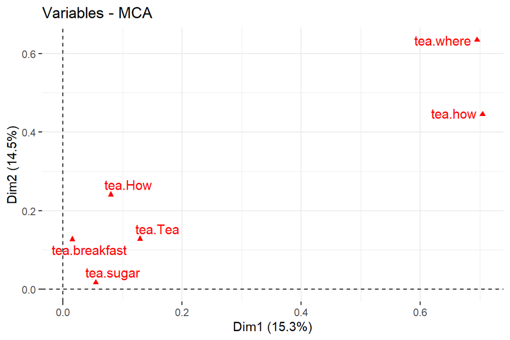

```r
# visualize MCA
fviz_mca_var(mca, choice = "mca.cor",
            repel = TRUE, # Avoid text overlapping (slow)
            ggtheme = theme_minimal())
```

W can also highlight the most important (or contributing) variable categories on the plot below. We can see that ‘unpacked’ and ‘tea shop’ contribute to the positive pole of dimension 1, while negative to the dimension 2. Vice versa for ‘milk’ and ‘breakfast’.

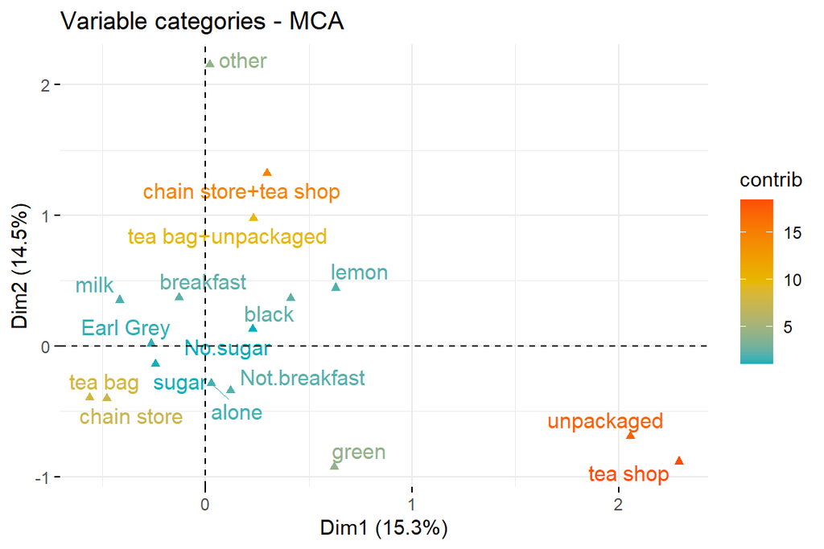

```r
fviz_mca_var(mca, col.var = "contrib",
             gradient.cols = c("#00AFBB", "#E7B800", "#FC4E07"),
             repel = TRUE, # avoid text overlapping (slow)
             ggtheme = theme_minimal()
             )
```

We can also visualize the individuals by groups using for example the levels of the variable ‘breakfast’. While ‘Not.breakfast’ is more to dimension 1, ‘breakfast’ is more to dimension 2.

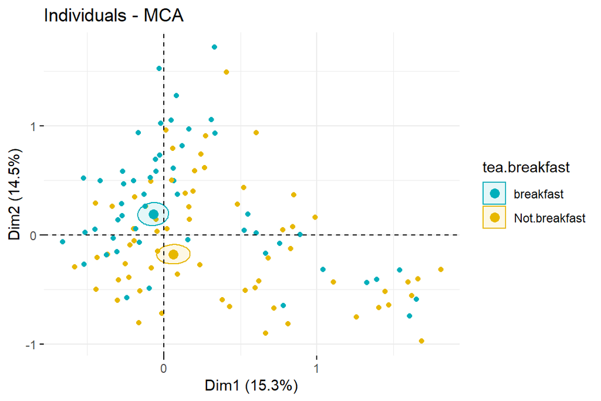

```r
# visualize MCA
fviz_mca_ind(mca,
             label = "none", # hide individual labels
             habillage = "tea.breakfast", # color by groups
             palette = c("#00AFBB", "#E7B800"),
             addEllipses = TRUE, ellipse.type = "confidence",
             ggtheme = theme_minimal())
```

Finally, we can visualize individuals using multiple categorical variables at the same time. We can see that ‘tea shop’ contributes positively to dimension 1, while negative to dimension 2. On the other hand, ‘chain store’ contributes negatively to both dimension 1 and dimension 2.

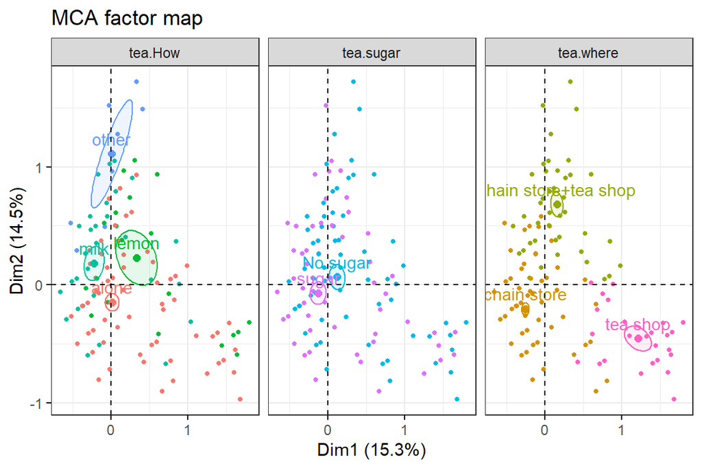

```r
# visualize MCA
fviz_ellipses(mca, c("tea.How", "tea.sugar", "tea.where"),
              geom = "point")
```

P.S. Visualizations in this MCA Section are mostly adopted from http://www.sthda.com/english/articles/31-principal-component-methods-in-r-practical-guide/114-mca-multiple-correspondence-analysis-in-r-essentials/.

*This is the end of the report*

```r
date()
```

```
## [1] "Sun Dec 05 15:49:21 2021"
```